# Raport 3

# Najlepsze kodowanie

Wyniki pracy dla nowego algorytmu. Walidacja krzyżowa 5-krotna, 8 powtórzeń.

|  | Length of sequences in training set | Number of clusters | Encoding | Mean AUC |
| --- | --- | --- | --- | --- |
| 1 | <16 | 6 | 91 | 0.8414 |
| 2 | <11 | 6 | 79 | 0.8341 |
| 3 | <16 | 6 | 87 | 0.8320 |
| 4 | <16 | 6 | 77 | 0.8307 |
| 5 | <16 | 6 | 69 | 0.8292 |
| 6 | <11 | 6 | 73 | 0.8285 |
| 7 | <11 | 6 | 86 | 0.8272 |
| 8 | <11 | 6 | 95 | 0.8265 |
| 9 | <16 | 6 | 70 | 0.8260 |
| 10 | <11 | 6 | 91 | 0.8258 |
| 11 | <16 | 6 | 73 | 0.8258 |
| 12 | <11 | 6 | 87 | 0.8250 |
| 13 | <11 | 4 | 45 | 0.8246 |
| 14 | <16 | 6 | 71 | 0.8230 |
| 15 | <11 | 5 | 60 | 0.8229 |

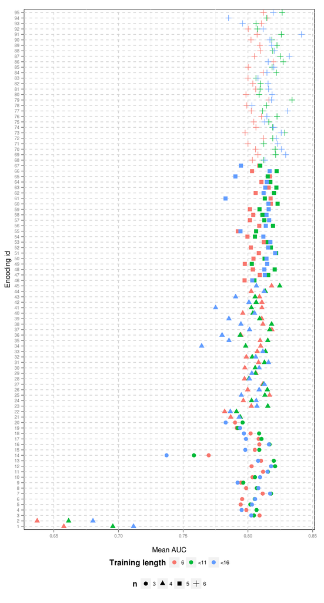

Wpływ kodowania na AUC. Kolorami zaznaczono rodzaje grup treningowych, a kształtem punktu liczbę klastrów w kodowaniu.

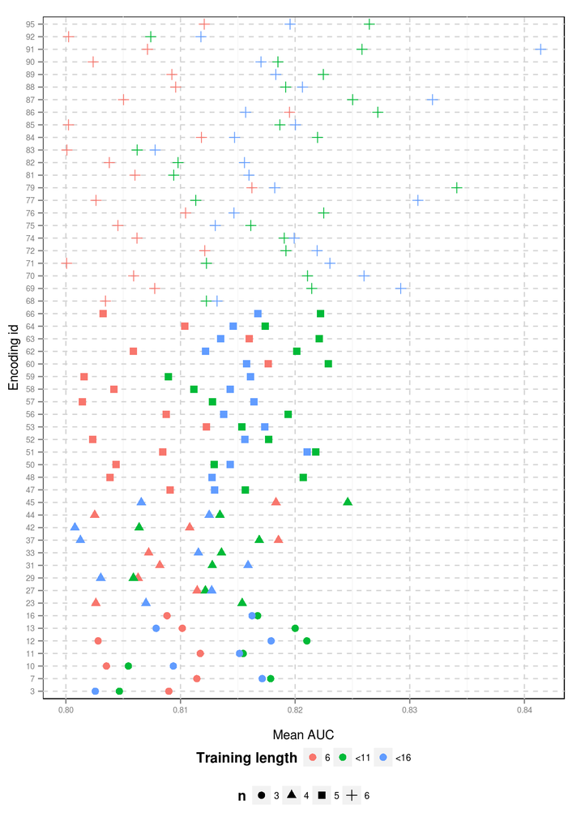

Wpływ kodowania na AUC. Kolorami zaznaczono rodzaje grup treningowych, a kształtem punktu liczbę klastrów w kodowaniu. Na rysunku przedstawiono wyłącznie kodowania, gdzie dla wszystkich grup treningowych wartość AUC przekraczała 0.8.

Interesujące kodowania:  
* 3 i 37: kodowania dla których heksagramy były najlepszym zbiorem uczącym,  
* 91: najlepsze kodowanie, ale z dużą różnicą dla zbioru uczącego.

# Najlepsze kodowanie dla danej kombinacji zbioru uczącego i liczby grup

Najlepsze kodowania dla danej kombinacji zbioru ucącego i liczby grup.

|  | Length of sequences in training set | Number of clusters | Encoding | Mean AUC |
| --- | --- | --- | --- | --- |
| 1 | 6 | 3 | 11 | 0.8117 |
| 2 | 6 | 4 | 37 | 0.8185 |
| 3 | 6 | 5 | 60 | 0.8177 |
| 4 | 6 | 6 | 86 | 0.8195 |
| 5 | <11 | 3 | 12 | 0.8210 |
| 6 | <11 | 4 | 45 | 0.8246 |
| 7 | <11 | 5 | 60 | 0.8229 |
| 8 | <11 | 6 | 79 | 0.8341 |
| 9 | <16 | 3 | 12 | 0.8179 |
| 10 | <16 | 4 | 31 | 0.8159 |
| 11 | <16 | 5 | 51 | 0.8210 |
| 12 | <16 | 6 | 91 | 0.8414 |

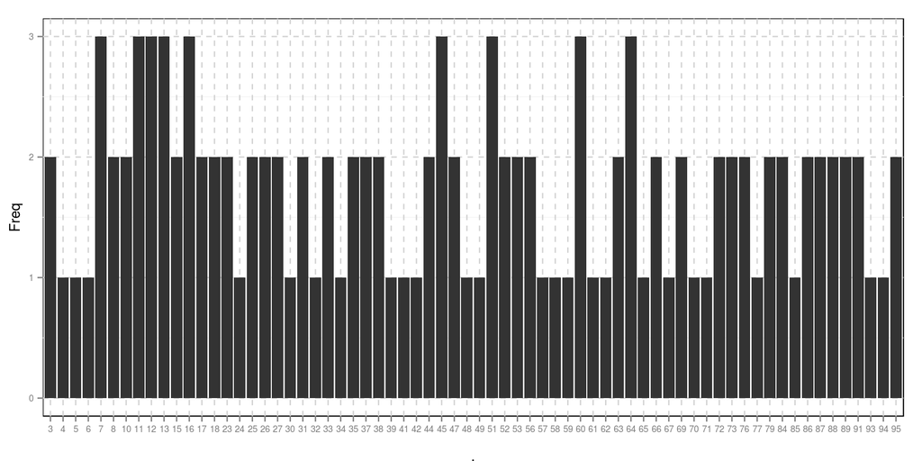

Na rysunku przedstawiono 10 najlepszych kodowań dla wszystkich kombinacji liczby grup i długości zbioru uczącego.

# Problemy porównywanie kodowań

Kodowania mogą różnić się rozłożeniem między grupami tylko jednego aminokwasu lub wszystkich aminokwasów. Należy wprowadzić miarę, która pozwoli na określenie odległości między kodowaniami o różnej liczbie grup.

Propozycja: liczba przesunięć aminokwasów między grupami w kodowaniu B, aby kodowanie B było identyczne z kodowaniem A.

Miara jest potrzebna, aby określić cechy łączące najlepsze kodowania.